# Simple Genetic Mixture Extensions

## Introduction

In this document I suggest two extensions of the inference problem for genetic mixtures. The first is to allow the mixture proportions, `w`, to be estimated rather than fixed. The second is to allow that the allele frequencies in different populations tend to be similar to one another (``correlated allele frequencies").

## The model

We begin by writing out the model more formally. We have genotypes $x$, allele frequencies $P$, and assignment labels $z$. The joint distribution is:
$$p(x, P, z) = p(P,z) p(x|P,z)$$
We assumed the prior distributions on $P$ and $z$ are independent, so:
$$p(x,P,z) = p(P) p(z) p(x | P,z).$$

In these expressions I kept things simple by not including the mixture proportions $w=(0.5,0.5)$ and the allele frequency prior parameters $a=(1,1)$, because they were both treated as fixed and known. Since we are going to change this I will put those in explicitly now:

$$p(x, P, z | w, a) = p(P| a) p(z | w) p(x|P,z)$$
Each term in this expression can be written out in more detail.

For example, we assumed independent beta priors on the elements of $P$ so:
$$p(P | a) = \prod_k \prod_r p(P_{kr} | a) \propto \prod_k \prod_r P_{kr}^{a_1-1} (1-P_{kr})^{a_2-1}$$
The $z$ were sampled independently according to $w=(w_1,w_2)$:
$$p(z | w) = \prod_i p(z_i | w) = \prod_i w_1^{I(z_i==1)} (1-w_1)^{I(z_i==2)}$$
And the genotypes for individual $i$ were then drawn from the allele frequencies of the relevant subpopulation $z_i$.
$$p(x | P,z) = \prod_i \prod_r P_{z_i r}^{x_i} (1-P_{z_i r})^{1-x_i}$$

## Estimate `w`

Now suppose we want to add the facility to estimate $w$ rather than treat it as fixed. We can proceed to specify a prior distribution for $w$ and do Bayesian inference.

The model becomes:
$$p(x, P, z, w | a) = p(P| a) p(z | w) p(w) p(x|P,z)$$

Note that the full conditional for $w$ is then given by:
$$p(w | x, P, z, a) \propto p(x,P,z,w|a) \propto p(z|w) p(w).$$
That is, it is obtained by taking full joint distribution of everything in our model, and ignoring the terms that do not depend on $w$. (This is generally true for the full conditional distributions: to find the full conditional of a parameter, write down the joint distribution and ignore terms that do not depend on the parameter.)

The sampling of $z|w$ is effectively binomial, and indeed:
$$p(z|w) \propto w_1^{n_1}(1-w_1)^{n_2}$$
where
$$n_1 := \#\{z_i: z_i==1\}$$
and
$$n_2 := \#\{z_i: z_i==2\}$$
.

So if we use a beta prior for $w$, say
$$w \sim Beta(b_1, b_2)$$
then the full conditional for $w$ will also be a beta distribution. Can you write down the parameters of this posterior?

Thus we can sample from the full conditional for $w$. This means we can include it in our MCMC scheme using a Gibbs step. The extended Gibbs algorithm, in outline, will look like this:

Iterate:

1. sample `P` from `P` | `z`, `w`, `x`
2. sample `z` from `z` | `P`, `w`, `x`
3. sample `w` from `w` | `P`, `z`, `x`

(Note that step 1 does not actually depend on `w`, and step 3 does not actually depend on `x`).

## Correlated allele frequencies

Now for a more challenging extension. In the above we assumed priors the allele frequences in the two populations are independent. But in practice, when you look at two populations, it is often the case that the allele frequencies will be somewhat similar.

Here we can introduce this by changing the prior on `P`. We will still assume beta priors, but we will let the mean of this beta prior change from locus to locus, and use the same mean for both populations. This will induce a correlation between the allele frequency for population 1 and for population 2.

Specifically I will begin by allowing the parameters of the Beta prior to change from locus to locus:
$$P_{kr} \sim Be(a_{1r},a_{2r})$$
One problem here is that $a_{1r}$ and $a_{2r}$ are a bit difficult to interpret - and their interpretation kind of depends on one another. Also, I now have a lot of parameters…

To solve these problems I will reparameterize the Beta distribution in terms of its mean $m_r := a_{1r}/(a_{1r}+a_{2r})$ and the sum $N_r := a_{1r} + a_{2r}$ which determines the variance, and I will reduce the number of parameters by assuming $N_r$ is the same for all loci, $N_r=N$.

So we can write
$$P_{kr} | m_r, N \sim Be(m_r N, (1-m_r)N)$$
Now I will put a prior on $m_r$. Since $m_r$ is a number between 0 and 1 I will use a uniform prior.

The value of $N$ determines the strength of the correlation between populations: if $N$ is big, then $P_{kr}$ will be very close to $m_r$ for both $k$. For simplicity I will just fix $N=10$ for now, which will give a modest correlation. As a further extension you could imagine also putting a prior on $N$ and estimating $N$ from the data.

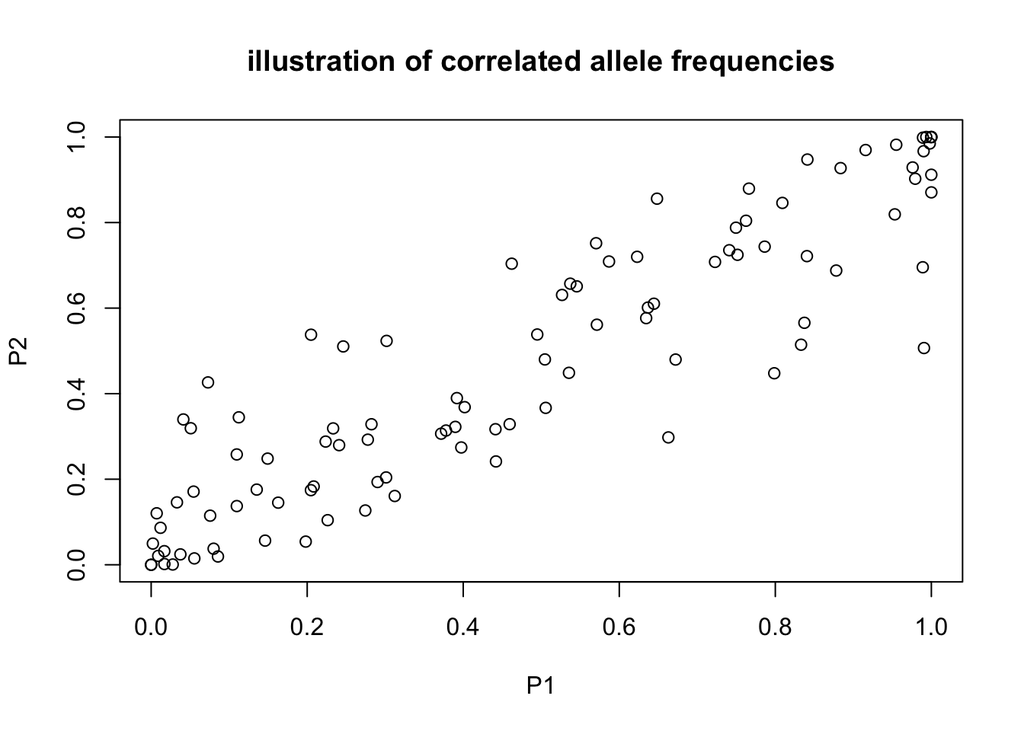

```r
set.seed(1001)
R = 100
m = runif(R)
N = 10
P1 = rbeta(R, m*N, (1-m)*N)
P2 = rbeta(R, m*N, (1-m)*N)
plot(P1,P2,main="illustration of correlated allele frequencies")
```

So to summarize the model we have:
$$p(x, P, z, w, m | N) = p(m) p(P| m, N) p(z | w) p(w) p(x|P,z)$$
Given $m,N$ the prior on $P_{kl}$ is still Beta, and so the full conditional of $P$ is still Beta (now with different prior parameters for each locus, but this does not complicate things too much).

Also the full conditionals for $z$ and $w$ have not changed, so we can keep the Gibbs updates for those….

So we are just left with $m$. However, the full conditional on $m$ is not tractable. It does not have a nice form and we cannot sample from it. The solution is to use a MH update for $m$, and mix it in with the Gibbs sampling updates! Remember that there is a separate $m$ parameter for each locus, which is a lot of parameters if there are a lot of loci. Also the loci are independent. So it makes sense to update each $m_r$ parameter separately using component-wise MH, rather than jointly. The update function might look something like this:

```r
update_m_MH = function(P,N){
  R = ncol(P)
  for(r in 1:R){
    proposed_m = m[r] + rnorm(1,0,0.1)
    A = ...
    if(runif(1)<A)
      m[r] = proposed_m
  }
  return(m)
}
```